# LEARN SEABORN PYTHON LIBRARY

**seaborn line plot**

```python
import seaborn as sns
import matplotlib.pyplot as plt
import pandas as pd
import numpy as np
```

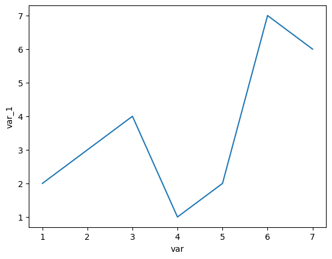

```python
var=[1,2,3,4,5,6,7]
var_1=[2,3,4,1,2,7,6]

x_1=pd.DataFrame({"var":var,"var_1":var_1})

sns.lineplot(x="var",y="var_1",data=x_1)

plt.show()
```

**we can plot without dataframe but label will not be showed in that case and matplotlib type graph shown**

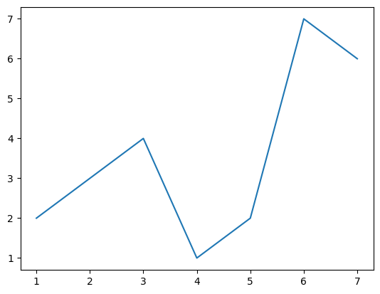

```python
var=[1,2,3,4,5,6,7]
var_1=[2,3,4,1,2,7,6]
sns.lineplot(x=var,y=var_1)

plt.show()
```

**now we use real type data set file to work on it through seaborn and plot line graph between two data**

```python
y_1=sns.load_dataset("penguins")
```

```python
y_1
```

|  | species | island | bill_length_mm | bill_depth_mm | flipper_length_mm | body_mass_g | sex |
| --- | --- | --- | --- | --- | --- | --- | --- |
| 0 | Adelie | Torgersen | 39.1 | 18.7 | 181.0 | 3750.0 | Male |
| 1 | Adelie | Torgersen | 39.5 | 17.4 | 186.0 | 3800.0 | Female |
| 2 | Adelie | Torgersen | 40.3 | 18.0 | 195.0 | 3250.0 | Female |
| 3 | Adelie | Torgersen | NaN | NaN | NaN | NaN | NaN |
| 4 | Adelie | Torgersen | 36.7 | 19.3 | 193.0 | 3450.0 | Female |
| ... | ... | ... | ... | ... | ... | ... | ... |
| 339 | Gentoo | Biscoe | NaN | NaN | NaN | NaN | NaN |
| 340 | Gentoo | Biscoe | 46.8 | 14.3 | 215.0 | 4850.0 | Female |
| 341 | Gentoo | Biscoe | 50.4 | 15.7 | 222.0 | 5750.0 | Male |
| 342 | Gentoo | Biscoe | 45.2 | 14.8 | 212.0 | 5200.0 | Female |
| 343 | Gentoo | Biscoe | 49.9 | 16.1 | 213.0 | 5400.0 | Male |

344 rows × 7 columns

**"Hue parameter": used to plot graph between two with respect to popular data in dataset automatically, as mentioned below sex is popular data here**

**"palette parameter": used to change the color of plot**

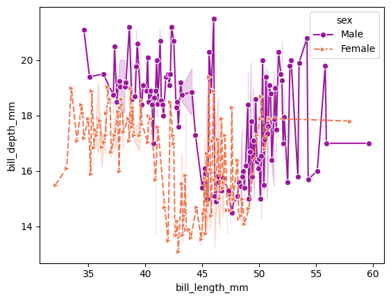

```python
sns.lineplot(x="bill_length_mm",y="bill_depth_mm",
             data=y_1,hue="sex",style="sex",palette="plasma",
             markers=["o",">"])
plt.show()
```

**PLOT LINE FOR ONLY FEW AMOUNT OF DATA USING HEAD FUNCTION SO PLOTTED GRAPH SHOWED ACCORDINGLY**

```python
y_1=sns.load_dataset("penguins").head(20)
y_1
```

|  | species | island | bill_length_mm | bill_depth_mm | flipper_length_mm | body_mass_g | sex |
| --- | --- | --- | --- | --- | --- | --- | --- |
| 0 | Adelie | Torgersen | 39.1 | 18.7 | 181.0 | 3750.0 | Male |
| 1 | Adelie | Torgersen | 39.5 | 17.4 | 186.0 | 3800.0 | Female |
| 2 | Adelie | Torgersen | 40.3 | 18.0 | 195.0 | 3250.0 | Female |
| 3 | Adelie | Torgersen | NaN | NaN | NaN | NaN | NaN |
| 4 | Adelie | Torgersen | 36.7 | 19.3 | 193.0 | 3450.0 | Female |
| 5 | Adelie | Torgersen | 39.3 | 20.6 | 190.0 | 3650.0 | Male |
| 6 | Adelie | Torgersen | 38.9 | 17.8 | 181.0 | 3625.0 | Female |
| 7 | Adelie | Torgersen | 39.2 | 19.6 | 195.0 | 4675.0 | Male |
| 8 | Adelie | Torgersen | 34.1 | 18.1 | 193.0 | 3475.0 | NaN |
| 9 | Adelie | Torgersen | 42.0 | 20.2 | 190.0 | 4250.0 | NaN |
| 10 | Adelie | Torgersen | 37.8 | 17.1 | 186.0 | 3300.0 | NaN |
| 11 | Adelie | Torgersen | 37.8 | 17.3 | 180.0 | 3700.0 | NaN |
| 12 | Adelie | Torgersen | 41.1 | 17.6 | 182.0 | 3200.0 | Female |
| 13 | Adelie | Torgersen | 38.6 | 21.2 | 191.0 | 3800.0 | Male |
| 14 | Adelie | Torgersen | 34.6 | 21.1 | 198.0 | 4400.0 | Male |
| 15 | Adelie | Torgersen | 36.6 | 17.8 | 185.0 | 3700.0 | Female |
| 16 | Adelie | Torgersen | 38.7 | 19.0 | 195.0 | 3450.0 | Female |
| 17 | Adelie | Torgersen | 42.5 | 20.7 | 197.0 | 4500.0 | Male |
| 18 | Adelie | Torgersen | 34.4 | 18.4 | 184.0 | 3325.0 | Female |
| 19 | Adelie | Torgersen | 46.0 | 21.5 | 194.0 | 4200.0 | Male |

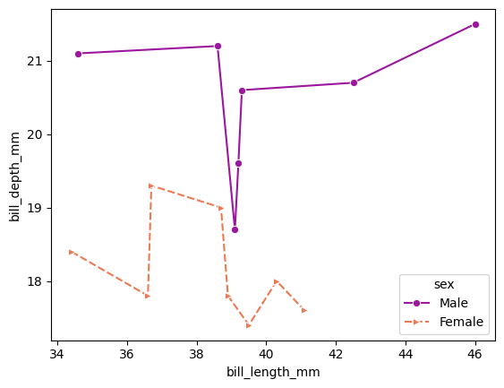

```python
sns.lineplot(x="bill_length_mm",y="bill_depth_mm",
             data=y_1,hue="sex",style="sex",palette="plasma",
             markers=["o",">"])
plt.show()
```

**we can use dashes parameter to remove dotted line by giving it false OR "In seaborn legend() function is used to remove legend of plot but if not used then it has always legend on graph"**

**now we used grid ot title parameter**

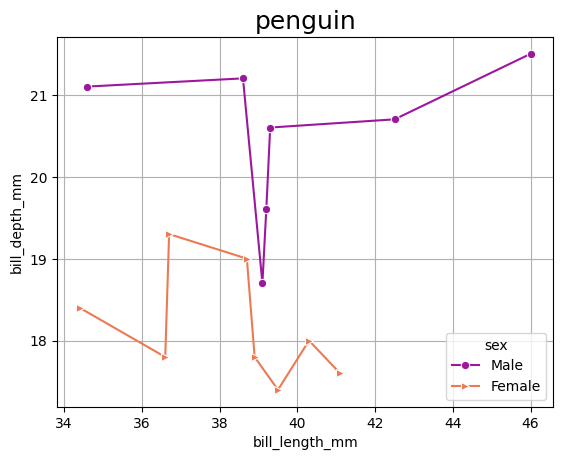

```python
sns.lineplot(x="bill_length_mm",y="bill_depth_mm",
             data=y_1,hue="sex",style="sex",palette="plasma",
             markers=["o",">"],dashes=False)

plt.title("penguin",fontsize=18)
plt.grid()
plt.show()
```

# histogram plot method in seaborn

```python
df=sns.load_dataset("titanic")
df
```

|  | survived | pclass | sex | age | sibsp | parch | fare | embarked | class | who | adult_male | deck | embark_town | alive | alone |
| --- | --- | --- | --- | --- | --- | --- | --- | --- | --- | --- | --- | --- | --- | --- | --- |
| 0 | 0 | 3 | male | 22.0 | 1 | 0 | 7.2500 | S | Third | man | True | NaN | Southampton | no | False |
| 1 | 1 | 1 | female | 38.0 | 1 | 0 | 71.2833 | C | First | woman | False | C | Cherbourg | yes | False |
| 2 | 1 | 3 | female | 26.0 | 0 | 0 | 7.9250 | S | Third | woman | False | NaN | Southampton | yes | True |
| 3 | 1 | 1 | female | 35.0 | 1 | 0 | 53.1000 | S | First | woman | False | C | Southampton | yes | False |
| 4 | 0 | 3 | male | 35.0 | 0 | 0 | 8.0500 | S | Third | man | True | NaN | Southampton | no | True |
| ... | ... | ... | ... | ... | ... | ... | ... | ... | ... | ... | ... | ... | ... | ... | ... |
| 886 | 0 | 2 | male | 27.0 | 0 | 0 | 13.0000 | S | Second | man | True | NaN | Southampton | no | True |
| 887 | 1 | 1 | female | 19.0 | 0 | 0 | 30.0000 | S | First | woman | False | B | Southampton | yes | True |
| 888 | 0 | 3 | female | NaN | 1 | 2 | 23.4500 | S | Third | woman | False | NaN | Southampton | no | False |
| 889 | 1 | 1 | male | 26.0 | 0 | 0 | 30.0000 | C | First | man | True | C | Cherbourg | yes | True |
| 890 | 0 | 3 | male | 32.0 | 0 | 0 | 7.7500 | Q | Third | man | True | NaN | Queenstown | no | True |

891 rows × 15 columns

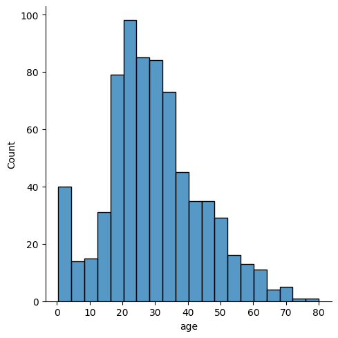

```python
sns.displot(df["age"])
plt.show()
```

**bins=[] parameter used to define the range of data for plotted graph which shows exact value range through plot**

**kde parameter stands dor kernel density estimator it shows a line estimaton graph on histplot used with rug parameter shows scaling**

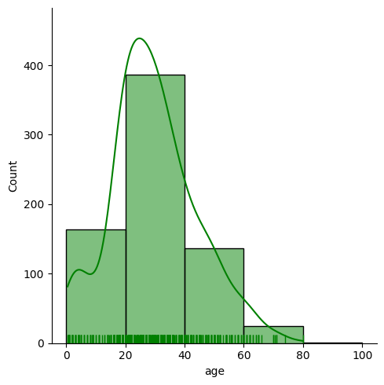

```python
sns.displot(df["age"],bins=[0,20,40,60,80,100],kde=True,rug=True,
            color="g")
plt.show()
```

# PLOTTING BAR CHART IN SEABORN

```python
import seaborn as sns
import matplotlib.pyplot as plt
import pandas as pd
import numpy as np

df=sns.load_dataset("penguins")
df
```

|  | species | island | bill_length_mm | bill_depth_mm | flipper_length_mm | body_mass_g | sex |
| --- | --- | --- | --- | --- | --- | --- | --- |
| 0 | Adelie | Torgersen | 39.1 | 18.7 | 181.0 | 3750.0 | Male |
| 1 | Adelie | Torgersen | 39.5 | 17.4 | 186.0 | 3800.0 | Female |
| 2 | Adelie | Torgersen | 40.3 | 18.0 | 195.0 | 3250.0 | Female |
| 3 | Adelie | Torgersen | NaN | NaN | NaN | NaN | NaN |
| 4 | Adelie | Torgersen | 36.7 | 19.3 | 193.0 | 3450.0 | Female |
| ... | ... | ... | ... | ... | ... | ... | ... |
| 339 | Gentoo | Biscoe | NaN | NaN | NaN | NaN | NaN |
| 340 | Gentoo | Biscoe | 46.8 | 14.3 | 215.0 | 4850.0 | Female |
| 341 | Gentoo | Biscoe | 50.4 | 15.7 | 222.0 | 5750.0 | Male |
| 342 | Gentoo | Biscoe | 45.2 | 14.8 | 212.0 | 5200.0 | Female |
| 343 | Gentoo | Biscoe | 49.9 | 16.1 | 213.0 | 5400.0 | Male |

344 rows × 7 columns

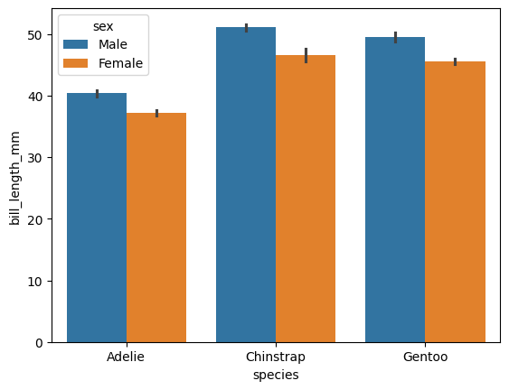

```python
sns.barplot(x="species",y="bill_length_mm",data=df,
            hue="sex")
plt.show()
```

**change the graph by any order or changing the sex data plot order according to hue_order parameter**

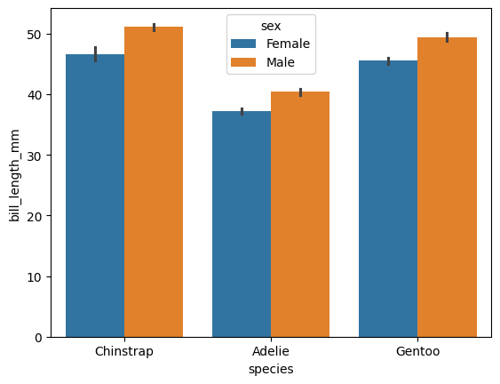

```python
order_1=["Chinstrap","Adelie","Gentoo"]
sns.barplot(x="species",y="bill_length_mm",data=df,
            hue="sex",order=order_1,hue_order=["Female","Male"],
            )
plt.show()
```

**for orientation to be horizontal so only apply on numeric data not on string data column**

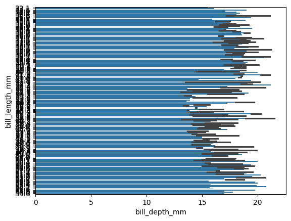

```python
sns.barplot(x="bill_depth_mm",y="bill_length_mm",
            data=df,orient="h")
plt.show()
```

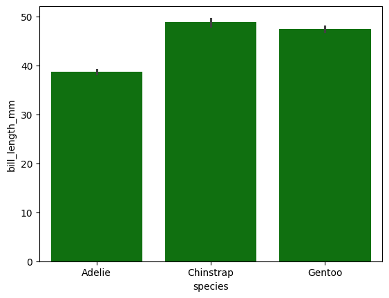

```python
sns.barplot(x="species",y="bill_length_mm",
            data=df,color="g")
plt.show()
```

we can change the saturation also with parameter

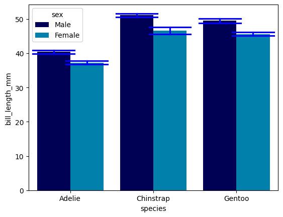

```python
sns.barplot(x="species",y="bill_length_mm",data=df,
            hue="sex",palette="ocean",saturation=1,
            err_kws={'color': 'b'},
            capsize=1)
plt.show()
```

**by using sns.set(style="darkgrid") grid will be removed**

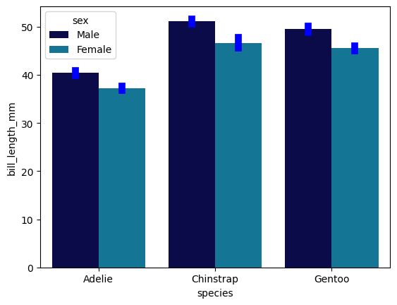

```python
sns.barplot(x="species",y="bill_length_mm",data=df,
            hue="sex",palette="ocean",
            err_kws={'color': 'b','linewidth':7},alpha=1)
plt.show()
```

# SCATTER PLOT METHOD IN SEABORN

```python
import seaborn as sns
import matplotlib.pyplot as plt
import pandas as pd
import numpy as np

df=sns.load_dataset("penguins").head(20)
df
```

|  | species | island | bill_length_mm | bill_depth_mm | flipper_length_mm | body_mass_g | sex |
| --- | --- | --- | --- | --- | --- | --- | --- |
| 0 | Adelie | Torgersen | 39.1 | 18.7 | 181.0 | 3750.0 | Male |
| 1 | Adelie | Torgersen | 39.5 | 17.4 | 186.0 | 3800.0 | Female |
| 2 | Adelie | Torgersen | 40.3 | 18.0 | 195.0 | 3250.0 | Female |
| 3 | Adelie | Torgersen | NaN | NaN | NaN | NaN | NaN |
| 4 | Adelie | Torgersen | 36.7 | 19.3 | 193.0 | 3450.0 | Female |
| 5 | Adelie | Torgersen | 39.3 | 20.6 | 190.0 | 3650.0 | Male |
| 6 | Adelie | Torgersen | 38.9 | 17.8 | 181.0 | 3625.0 | Female |
| 7 | Adelie | Torgersen | 39.2 | 19.6 | 195.0 | 4675.0 | Male |
| 8 | Adelie | Torgersen | 34.1 | 18.1 | 193.0 | 3475.0 | NaN |
| 9 | Adelie | Torgersen | 42.0 | 20.2 | 190.0 | 4250.0 | NaN |
| 10 | Adelie | Torgersen | 37.8 | 17.1 | 186.0 | 3300.0 | NaN |
| 11 | Adelie | Torgersen | 37.8 | 17.3 | 180.0 | 3700.0 | NaN |
| 12 | Adelie | Torgersen | 41.1 | 17.6 | 182.0 | 3200.0 | Female |
| 13 | Adelie | Torgersen | 38.6 | 21.2 | 191.0 | 3800.0 | Male |
| 14 | Adelie | Torgersen | 34.6 | 21.1 | 198.0 | 4400.0 | Male |
| 15 | Adelie | Torgersen | 36.6 | 17.8 | 185.0 | 3700.0 | Female |
| 16 | Adelie | Torgersen | 38.7 | 19.0 | 195.0 | 3450.0 | Female |
| 17 | Adelie | Torgersen | 42.5 | 20.7 | 197.0 | 4500.0 | Male |
| 18 | Adelie | Torgersen | 34.4 | 18.4 | 184.0 | 3325.0 | Female |
| 19 | Adelie | Torgersen | 46.0 | 21.5 | 194.0 | 4200.0 | Male |

we can increase the size of graph pointers using sizes parameter

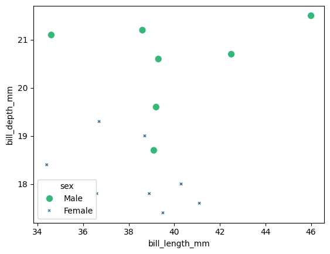

```python
sns.scatterplot(x="bill_length_mm",y="bill_depth_mm",data=df,
                hue="sex",style="sex",size="sex",
                palette="viridis_r")
plt.show()
```

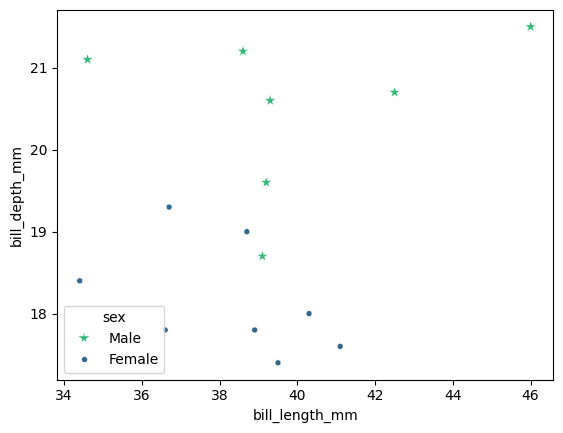

```python
m={"Male":"*","Female":"o"}
sns.scatterplot(x="bill_length_mm",y="bill_depth_mm",data=df,
                hue="sex",style="sex",size="sex",
                palette="viridis_r",markers=m)
plt.show()
```

# HEATMAP METHOD OF PLOTTING IN SEABORN

```python
import seaborn as sns
import matplotlib.pyplot as plt
import pandas as pd
import numpy as np
```

```python
df=np.linspace(1,10,20).reshape(4,5)
df
```

```
array([[ 1.        ,  1.47368421,  1.94736842,  2.42105263,  2.89473684],
       [ 3.36842105,  3.84210526,  4.31578947,  4.78947368,  5.26315789],
       [ 5.73684211,  6.21052632,  6.68421053,  7.15789474,  7.63157895],
       [ 8.10526316,  8.57894737,  9.05263158,  9.52631579, 10.        ]])
```

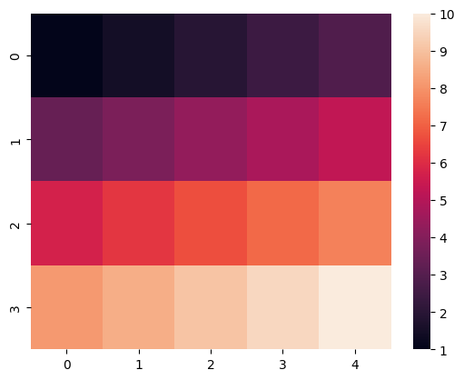

```python
sns.heatmap(df)
plt.show()
```

```python
dff=sns.load_dataset("anagrams")
x=dff.drop(columns=["attnr"],axis=1).head(15)
x
```

|  | subidr | num1 | num2 | num3 |
| --- | --- | --- | --- | --- |
| 0 | 1 | 2 | 4.0 | 7 |
| 1 | 2 | 3 | 4.0 | 5 |
| 2 | 3 | 3 | 5.0 | 6 |
| 3 | 4 | 5 | 7.0 | 5 |
| 4 | 5 | 4 | 5.0 | 8 |
| 5 | 6 | 5 | 5.0 | 6 |
| 6 | 7 | 5 | 4.5 | 6 |
| 7 | 8 | 5 | 7.0 | 8 |
| 8 | 9 | 2 | 3.0 | 7 |
| 9 | 10 | 6 | 5.0 | 6 |
| 10 | 11 | 6 | 5.0 | 6 |
| 11 | 12 | 8 | 9.0 | 8 |
| 12 | 13 | 6 | 5.0 | 9 |
| 13 | 14 | 8 | 8.0 | 7 |
| 14 | 15 | 8 | 8.0 | 7 |

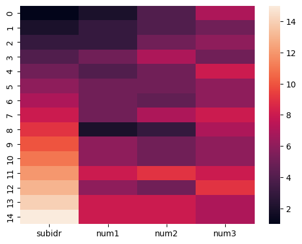

```python
sns.heatmap(x)
plt.show()
```

**some parameters as shown**

**annot parameter used to show the value on heatmap**

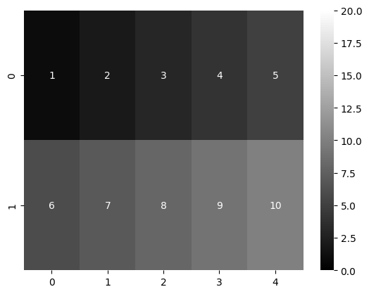

```python
df=np.linspace(1,10,10).reshape(2,5)
df
sns.heatmap(df,vmin=0,vmax=20,cmap="gist_gray",annot=True)
plt.show()
```

**using user input in place of annot parameter**

```python
ar=np.array([["a0","a1","a2","a3","a4"],
             ["b0","b1","b2","b3","b4"]])
ar
```

```
array([['a0', 'a1', 'a2', 'a3', 'a4'],
       ['b0', 'b1', 'b2', 'b3', 'b4']], dtype='<U2')
```

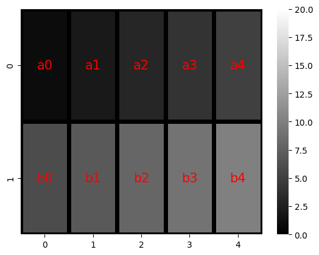

```python
y={"fontsize":15,"color":"r"}
sns.heatmap(df,vmin=0,vmax=20,cmap="gist_gray",
            annot=ar,fmt="s",annot_kws=y,linewidth=5,linecolor="black")
plt.show()
```

**to remove color map or label and set lable using set parameter**

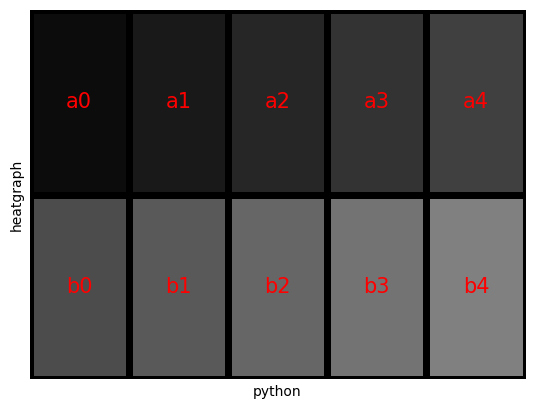

```python
y={"fontsize":15,"color":"r"}
v=sns.heatmap(df,vmin=0,vmax=20,cmap="gist_gray",
            annot=ar,fmt="s",annot_kws=y,linewidth=5,linecolor="black",
            cbar=False,xticklabels=False,yticklabels=False)

v.set(xlabel="python",ylabel="heatgraph")
plt.show()
```

# COUNT PLOT METHOD

```python
import seaborn as sns
import matplotlib.pyplot as plt
import pandas as pd
import numpy as np

pf=sns.load_dataset("tips")
pf
```

|  | total_bill | tip | sex | smoker | day | time | size |
| --- | --- | --- | --- | --- | --- | --- | --- |
| 0 | 16.99 | 1.01 | Female | No | Sun | Dinner | 2 |
| 1 | 10.34 | 1.66 | Male | No | Sun | Dinner | 3 |
| 2 | 21.01 | 3.50 | Male | No | Sun | Dinner | 3 |
| 3 | 23.68 | 3.31 | Male | No | Sun | Dinner | 2 |
| 4 | 24.59 | 3.61 | Female | No | Sun | Dinner | 4 |
| ... | ... | ... | ... | ... | ... | ... | ... |
| 239 | 29.03 | 5.92 | Male | No | Sat | Dinner | 3 |
| 240 | 27.18 | 2.00 | Female | Yes | Sat | Dinner | 2 |
| 241 | 22.67 | 2.00 | Male | Yes | Sat | Dinner | 2 |
| 242 | 17.82 | 1.75 | Male | No | Sat | Dinner | 2 |
| 243 | 18.78 | 3.00 | Female | No | Thur | Dinner | 2 |

244 rows × 7 columns

**Difference between countplot and barplot**

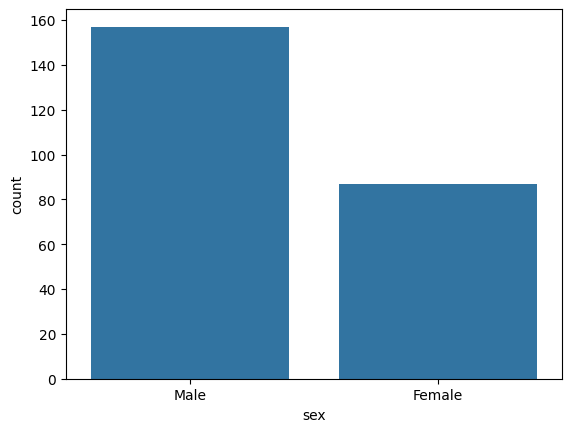

```python
sns.countplot(x="sex",data=pf)
plt.show()
```

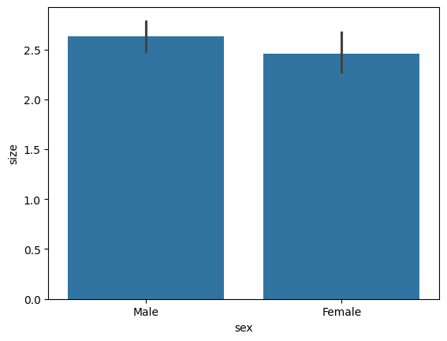

```python
sns.barplot(x="sex",y="size",data=pf)
plt.show()
```

some parameters and in horizontal view

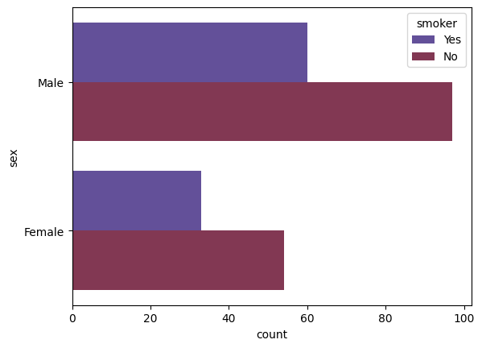

```python
sns.countplot(y="sex",data=pf,hue="smoker",palette="twilight")
plt.show()
```

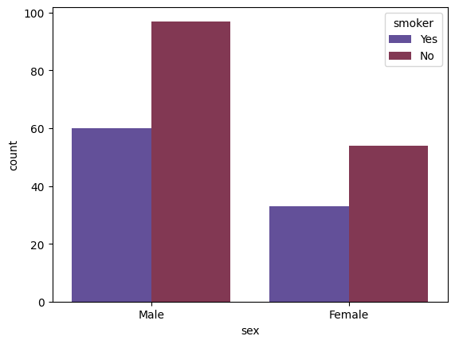

```python
sns.countplot(x="sex",data=pf,hue="smoker",palette="twilight")
plt.show()
```

## VIOLIN PLOT METHOD IN SEABORN

THIS PLOT PLAYS A SIMILAR ROLE AS BOX PLOT AND WHISKER PLOT

```python
import seaborn as sns
import matplotlib.pyplot as plt
import pandas as pd
import numpy as np

pf=sns.load_dataset("tips")
pf
```

|  | total_bill | tip | sex | smoker | day | time | size |
| --- | --- | --- | --- | --- | --- | --- | --- |
| 0 | 16.99 | 1.01 | Female | No | Sun | Dinner | 2 |
| 1 | 10.34 | 1.66 | Male | No | Sun | Dinner | 3 |
| 2 | 21.01 | 3.50 | Male | No | Sun | Dinner | 3 |
| 3 | 23.68 | 3.31 | Male | No | Sun | Dinner | 2 |
| 4 | 24.59 | 3.61 | Female | No | Sun | Dinner | 4 |
| ... | ... | ... | ... | ... | ... | ... | ... |
| 239 | 29.03 | 5.92 | Male | No | Sat | Dinner | 3 |
| 240 | 27.18 | 2.00 | Female | Yes | Sat | Dinner | 2 |
| 241 | 22.67 | 2.00 | Male | Yes | Sat | Dinner | 2 |
| 242 | 17.82 | 1.75 | Male | No | Sat | Dinner | 2 |
| 243 | 18.78 | 3.00 | Female | No | Thur | Dinner | 2 |

244 rows × 7 columns

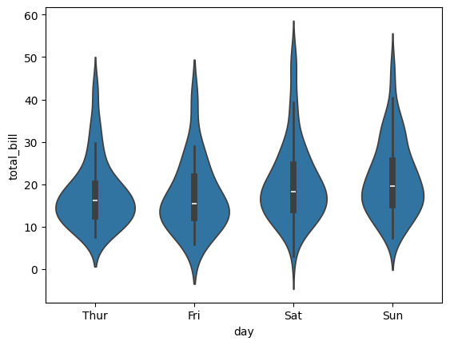

```python
sns.violinplot(x="day",y="total_bill",data=pf)
plt.show()
```

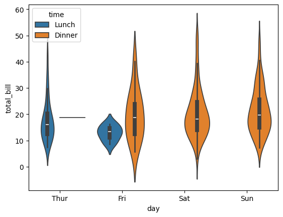

```python
sns.violinplot(x="day",y="total_bill",data=pf,hue="time")
plt.show()
```

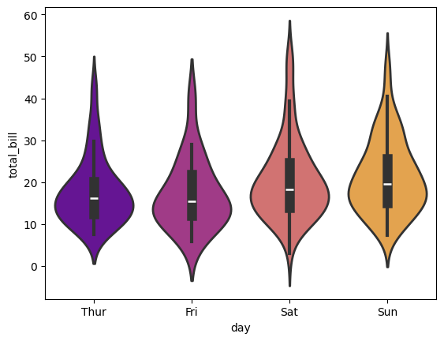

```python
sns.violinplot(x="day",y="total_bill",data=pf,linewidth=2,
               palette="plasma")
plt.show()
```

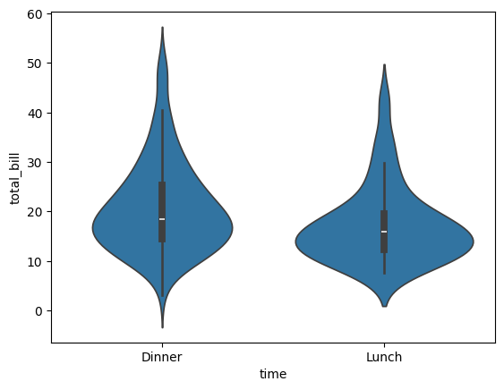

```python
sns.violinplot(x="time",y="total_bill",data=pf,
               order=["Dinner","Lunch"])
plt.show()
```

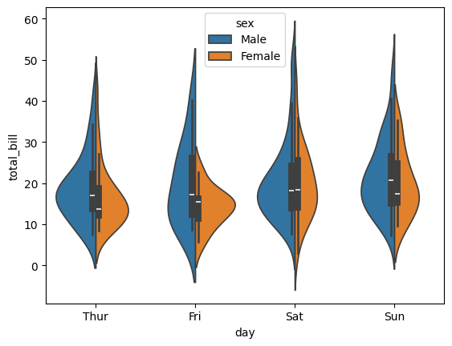

```python
sns.violinplot(x="day",y="total_bill",hue="sex",data=pf,split=True,
               )
plt.show()
```

**to change the inner part from box to other we use inner parameter other shapes are quartile,box,point,stick**

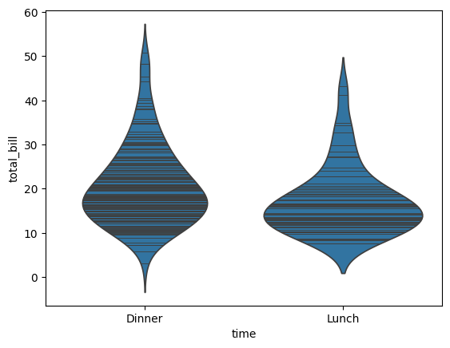

```python
sns.violinplot(x="time",y="total_bill",data=pf,order=["Dinner","Lunch"],
              inner="stick" )
plt.show()
```

**For single violin plot**

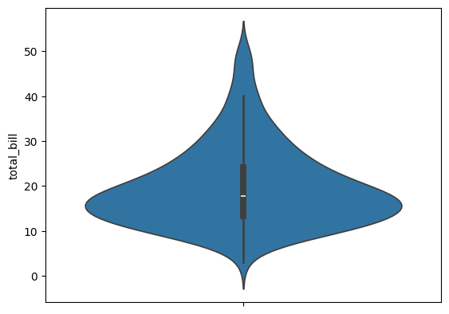

```python
sns.violinplot(y=pf["total_bill"])
plt.show()
```